# Risk Factor Analysis

## Outcome Variable

**Outcome Variable:** stunted

## Predictor Variables

**Intervention Variable:** mhtcm

**Adjustment Set:**

- arm
- W_mage
- meducyrs
- feducyrs
- single
- delta_W_mage
- delta_meducyrs
- delta_feducyrs
- delta_single

## Stratifying Variables

The analysis was stratified on these variable(s):

- agecat
- studyid
- country

## Data Summary

| agecat | studyid | country | mhtcm | stunted | n_cell | n |
| --- | --- | --- | --- | --- | --- | --- |
| Birth | ki0047075b-MAL-ED | BANGLADESH | >=160 | 0 | 4 | 246 |
| Birth | ki0047075b-MAL-ED | BANGLADESH | >=160 | 1 | 0 | 246 |
| Birth | ki0047075b-MAL-ED | BANGLADESH | <145 | 0 | 41 | 246 |
| Birth | ki0047075b-MAL-ED | BANGLADESH | <145 | 1 | 14 | 246 |
| Birth | ki0047075b-MAL-ED | BANGLADESH | [145-150) | 0 | 70 | 246 |
| Birth | ki0047075b-MAL-ED | BANGLADESH | [145-150) | 1 | 16 | 246 |
| Birth | ki0047075b-MAL-ED | BANGLADESH | [150-155) | 0 | 71 | 246 |
| Birth | ki0047075b-MAL-ED | BANGLADESH | [150-155) | 1 | 9 | 246 |
| Birth | ki0047075b-MAL-ED | BANGLADESH | [155-160) | 0 | 18 | 246 |
| Birth | ki0047075b-MAL-ED | BANGLADESH | [155-160) | 1 | 3 | 246 |
| 6 months | ki0047075b-MAL-ED | BANGLADESH | >=160 | 0 | 4 | 241 |
| 6 months | ki0047075b-MAL-ED | BANGLADESH | >=160 | 1 | 0 | 241 |
| 6 months | ki0047075b-MAL-ED | BANGLADESH | <145 | 0 | 37 | 241 |
| 6 months | ki0047075b-MAL-ED | BANGLADESH | <145 | 1 | 16 | 241 |
| 6 months | ki0047075b-MAL-ED | BANGLADESH | [145-150) | 0 | 67 | 241 |
| 6 months | ki0047075b-MAL-ED | BANGLADESH | [145-150) | 1 | 20 | 241 |
| 6 months | ki0047075b-MAL-ED | BANGLADESH | [150-155) | 0 | 71 | 241 |
| 6 months | ki0047075b-MAL-ED | BANGLADESH | [150-155) | 1 | 6 | 241 |
| 6 months | ki0047075b-MAL-ED | BANGLADESH | [155-160) | 0 | 17 | 241 |
| 6 months | ki0047075b-MAL-ED | BANGLADESH | [155-160) | 1 | 3 | 241 |
| 24 months | ki0047075b-MAL-ED | BANGLADESH | >=160 | 0 | 3 | 212 |
| 24 months | ki0047075b-MAL-ED | BANGLADESH | >=160 | 1 | 1 | 212 |
| 24 months | ki0047075b-MAL-ED | BANGLADESH | <145 | 0 | 14 | 212 |
| 24 months | ki0047075b-MAL-ED | BANGLADESH | <145 | 1 | 30 | 212 |
| 24 months | ki0047075b-MAL-ED | BANGLADESH | [145-150) | 0 | 38 | 212 |
| 24 months | ki0047075b-MAL-ED | BANGLADESH | [145-150) | 1 | 42 | 212 |
| 24 months | ki0047075b-MAL-ED | BANGLADESH | [150-155) | 0 | 44 | 212 |
| 24 months | ki0047075b-MAL-ED | BANGLADESH | [150-155) | 1 | 22 | 212 |
| 24 months | ki0047075b-MAL-ED | BANGLADESH | [155-160) | 0 | 15 | 212 |
| 24 months | ki0047075b-MAL-ED | BANGLADESH | [155-160) | 1 | 3 | 212 |

[output cut: 544 more lines]

The following strata were considered:

- agecat: 24 months, studyid: ki0047075b-MAL-ED, country: BANGLADESH
- agecat: 24 months, studyid: ki0047075b-MAL-ED, country: BRAZIL
- agecat: 24 months, studyid: ki0047075b-MAL-ED, country: INDIA
- agecat: 24 months, studyid: ki0047075b-MAL-ED, country: NEPAL
- agecat: 24 months, studyid: ki0047075b-MAL-ED, country: PERU
- agecat: 24 months, studyid: ki0047075b-MAL-ED, country: SOUTH AFRICA
- agecat: 24 months, studyid: ki0047075b-MAL-ED, country: TANZANIA, UNITED REPUBLIC OF
- agecat: 24 months, studyid: ki1017093-NIH-Birth, country: BANGLADESH
- agecat: 24 months, studyid: ki1017093b-PROVIDE, country: BANGLADESH
- agecat: 24 months, studyid: ki1017093c-NIH-Crypto, country: BANGLADESH
- agecat: 24 months, studyid: ki1066203-TanzaniaChild2, country: TANZANIA, UNITED REPUBLIC OF
- agecat: 24 months, studyid: ki1101329-Keneba, country: GAMBIA
- agecat: 24 months, studyid: ki1119695-PROBIT, country: BELARUS
- agecat: 24 months, studyid: ki1126311-ZVITAMBO, country: ZIMBABWE
- agecat: 24 months, studyid: ki1135781-COHORTS, country: GUATEMALA
- agecat: 24 months, studyid: ki1135781-COHORTS, country: INDIA
- agecat: 24 months, studyid: ki1135781-COHORTS, country: PHILIPPINES
- agecat: 24 months, studyid: ki1148112-LCNI-5, country: MALAWI
- agecat: 24 months, studyid: kiGH5241-JiVitA-3, country: BANGLADESH
- agecat: 6 months, studyid: ki0047075b-MAL-ED, country: BANGLADESH
- agecat: 6 months, studyid: ki0047075b-MAL-ED, country: BRAZIL
- agecat: 6 months, studyid: ki0047075b-MAL-ED, country: INDIA
- agecat: 6 months, studyid: ki0047075b-MAL-ED, country: NEPAL
- agecat: 6 months, studyid: ki0047075b-MAL-ED, country: PERU
- agecat: 6 months, studyid: ki0047075b-MAL-ED, country: SOUTH AFRICA
- agecat: 6 months, studyid: ki0047075b-MAL-ED, country: TANZANIA, UNITED REPUBLIC OF
- agecat: 6 months, studyid: ki1000304b-SAS-CompFeed, country: INDIA
- agecat: 6 months, studyid: ki1000304b-SAS-FoodSuppl, country: INDIA
- agecat: 6 months, studyid: ki1017093-NIH-Birth, country: BANGLADESH
- agecat: 6 months, studyid: ki1017093b-PROVIDE, country: BANGLADESH
- agecat: 6 months, studyid: ki1017093c-NIH-Crypto, country: BANGLADESH
- agecat: 6 months, studyid: ki1066203-TanzaniaChild2, country: TANZANIA, UNITED REPUBLIC OF
- agecat: 6 months, studyid: ki1101329-Keneba, country: GAMBIA
- agecat: 6 months, studyid: ki1112895-Guatemala BSC, country: GUATEMALA
- agecat: 6 months, studyid: ki1119695-PROBIT, country: BELARUS
- agecat: 6 months, studyid: ki1126311-ZVITAMBO, country: ZIMBABWE
- agecat: 6 months, studyid: ki1135781-COHORTS, country: GUATEMALA
- agecat: 6 months, studyid: ki1135781-COHORTS, country: INDIA
- agecat: 6 months, studyid: ki1135781-COHORTS, country: PHILIPPINES
- agecat: 6 months, studyid: ki1148112-LCNI-5, country: MALAWI
- agecat: 6 months, studyid: kiGH5241-JiVitA-3, country: BANGLADESH
- agecat: Birth, studyid: ki0047075b-MAL-ED, country: BANGLADESH
- agecat: Birth, studyid: ki0047075b-MAL-ED, country: BRAZIL
- agecat: Birth, studyid: ki0047075b-MAL-ED, country: INDIA
- agecat: Birth, studyid: ki0047075b-MAL-ED, country: NEPAL
- agecat: Birth, studyid: ki0047075b-MAL-ED, country: PERU
- agecat: Birth, studyid: ki0047075b-MAL-ED, country: SOUTH AFRICA
- agecat: Birth, studyid: ki0047075b-MAL-ED, country: TANZANIA, UNITED REPUBLIC OF
- agecat: Birth, studyid: ki1000304b-SAS-CompFeed, country: INDIA
- agecat: Birth, studyid: ki1017093-NIH-Birth, country: BANGLADESH
- agecat: Birth, studyid: ki1017093c-NIH-Crypto, country: BANGLADESH
- agecat: Birth, studyid: ki1101329-Keneba, country: GAMBIA
- agecat: Birth, studyid: ki1119695-PROBIT, country: BELARUS
- agecat: Birth, studyid: ki1126311-ZVITAMBO, country: ZIMBABWE
- agecat: Birth, studyid: ki1135781-COHORTS, country: GUATEMALA
- agecat: Birth, studyid: ki1135781-COHORTS, country: INDIA
- agecat: Birth, studyid: ki1135781-COHORTS, country: PHILIPPINES
- agecat: Birth, studyid: kiGH5241-JiVitA-3, country: BANGLADESH

### Dropped Strata

Some strata were dropped due to rare outcomes:

- agecat: Birth, studyid: ki0047075b-MAL-ED, country: BANGLADESH
- agecat: 6 months, studyid: ki0047075b-MAL-ED, country: BANGLADESH
- agecat: 24 months, studyid: ki0047075b-MAL-ED, country: BANGLADESH
- agecat: Birth, studyid: ki0047075b-MAL-ED, country: BRAZIL
- agecat: 6 months, studyid: ki0047075b-MAL-ED, country: BRAZIL
- agecat: 24 months, studyid: ki0047075b-MAL-ED, country: BRAZIL
- agecat: Birth, studyid: ki0047075b-MAL-ED, country: INDIA
- agecat: 6 months, studyid: ki0047075b-MAL-ED, country: INDIA
- agecat: 24 months, studyid: ki0047075b-MAL-ED, country: INDIA
- agecat: 6 months, studyid: ki0047075b-MAL-ED, country: NEPAL
- agecat: 24 months, studyid: ki0047075b-MAL-ED, country: NEPAL
- agecat: Birth, studyid: ki0047075b-MAL-ED, country: NEPAL
- agecat: Birth, studyid: ki0047075b-MAL-ED, country: PERU
- agecat: 6 months, studyid: ki0047075b-MAL-ED, country: PERU
- agecat: 24 months, studyid: ki0047075b-MAL-ED, country: PERU
- agecat: Birth, studyid: ki0047075b-MAL-ED, country: SOUTH AFRICA
- agecat: 6 months, studyid: ki0047075b-MAL-ED, country: SOUTH AFRICA
- agecat: 24 months, studyid: ki0047075b-MAL-ED, country: SOUTH AFRICA
- agecat: Birth, studyid: ki0047075b-MAL-ED, country: TANZANIA, UNITED REPUBLIC OF
- agecat: 6 months, studyid: ki0047075b-MAL-ED, country: TANZANIA, UNITED REPUBLIC OF
- agecat: 24 months, studyid: ki0047075b-MAL-ED, country: TANZANIA, UNITED REPUBLIC OF
- agecat: Birth, studyid: ki1000304b-SAS-CompFeed, country: INDIA
- agecat: 6 months, studyid: ki1000304b-SAS-FoodSuppl, country: INDIA
- agecat: 6 months, studyid: ki1017093-NIH-Birth, country: BANGLADESH
- agecat: 24 months, studyid: ki1017093-NIH-Birth, country: BANGLADESH
- agecat: Birth, studyid: ki1017093-NIH-Birth, country: BANGLADESH
- agecat: 6 months, studyid: ki1017093b-PROVIDE, country: BANGLADESH
- agecat: Birth, studyid: ki1017093c-NIH-Crypto, country: BANGLADESH
- agecat: 6 months, studyid: ki1017093c-NIH-Crypto, country: BANGLADESH
- agecat: 24 months, studyid: ki1017093c-NIH-Crypto, country: BANGLADESH
- agecat: 24 months, studyid: ki1066203-TanzaniaChild2, country: TANZANIA, UNITED REPUBLIC OF
- agecat: Birth, studyid: ki1101329-Keneba, country: GAMBIA
- agecat: 6 months, studyid: ki1101329-Keneba, country: GAMBIA
- agecat: 24 months, studyid: ki1101329-Keneba, country: GAMBIA
- agecat: 6 months, studyid: ki1112895-Guatemala BSC, country: GUATEMALA
- agecat: Birth, studyid: ki1119695-PROBIT, country: BELARUS
- agecat: 6 months, studyid: ki1119695-PROBIT, country: BELARUS
- agecat: 24 months, studyid: ki1119695-PROBIT, country: BELARUS
- agecat: 24 months, studyid: ki1126311-ZVITAMBO, country: ZIMBABWE
- agecat: Birth, studyid: ki1135781-COHORTS, country: GUATEMALA
- agecat: 6 months, studyid: ki1135781-COHORTS, country: GUATEMALA
- agecat: Birth, studyid: ki1135781-COHORTS, country: PHILIPPINES
- agecat: 6 months, studyid: ki1148112-LCNI-5, country: MALAWI
- agecat: 24 months, studyid: ki1148112-LCNI-5, country: MALAWI

## Methods Detail

We’re interested in the causal parameters $E[Y_a]$ for all values of $a \in \mathcal{A}$. These parameters represent the mean outcome if, possibly contrary to fact, we intervened to set all units to have $A=a$. Under the randomization and positivity assumptions, these are identified by the statistical parameters $\psi_a=E_W[E_{Y|A,W}(Y|A=a,W)]$. In addition, we’re interested in the mean of $Y$, $E[Y]$ under no intervention (the observed mean). We will estimate these parameters by using SuperLearner to fit the relevant likelihood factors – $E_{Y|A,W}(Y|A=a,W)$ and $p(A=a|W)$, and then updating our likelihood fit using a joint TMLE.

For unadjusted analyses ($W=\{\}$), initial likelihoods were estimated using Lrnr_glm to estimate the simple $E(Y|A)$ and Lrnr_mean to estimate $p(A)$. For adjusted analyses, a small library containing Lrnr_glmnet, Lrnr_xgboost, and Lrnr_mean was used.

Having estimated these parameters, we will then use the delta method to estimate relative risks and attributable risks relative to a prespecified baseline level of $A$.

# Results Detail

## Results Plots

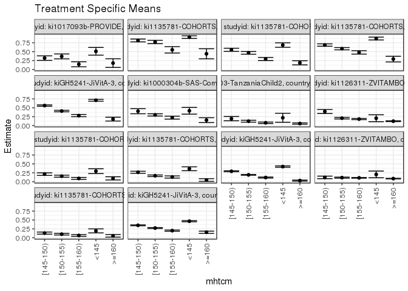

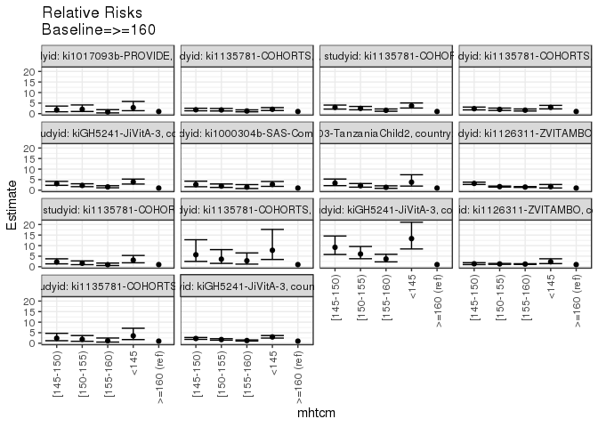

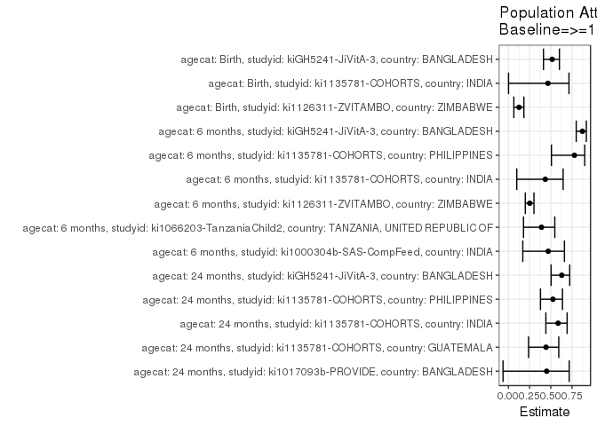

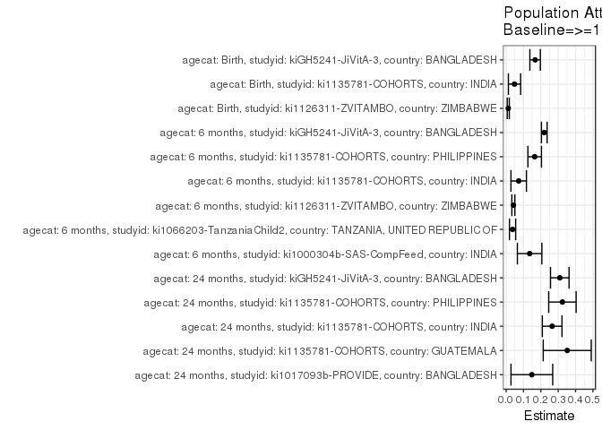

## Results Table

### Parameter: TSM

| agecat | studyid | country | intervention_level | baseline_level | estimate | ci_lower | ci_upper |
| --- | --- | --- | --- | --- | --- | --- | --- |
| Birth | ki1126311-ZVITAMBO | ZIMBABWE | >=160 | NA | 0.0866987 | 0.0787966 | 0.0946008 |
| Birth | ki1126311-ZVITAMBO | ZIMBABWE | <145 | NA | 0.2037647 | 0.1095084 | 0.2980209 |
| Birth | ki1126311-ZVITAMBO | ZIMBABWE | [145-150) | NA | 0.1205954 | 0.0846601 | 0.1565307 |
| Birth | ki1126311-ZVITAMBO | ZIMBABWE | [150-155) | NA | 0.1138611 | 0.0984140 | 0.1293083 |
| Birth | ki1126311-ZVITAMBO | ZIMBABWE | [155-160) | NA | 0.1075650 | 0.0962358 | 0.1188943 |
| Birth | ki1135781-COHORTS | INDIA | >=160 | NA | 0.0553574 | 0.0198348 | 0.0908800 |
| Birth | ki1135781-COHORTS | INDIA | <145 | NA | 0.1946896 | 0.1383623 | 0.2510168 |
| Birth | ki1135781-COHORTS | INDIA | [145-150) | NA | 0.1319270 | 0.1022756 | 0.1615784 |
| Birth | ki1135781-COHORTS | INDIA | [150-155) | NA | 0.1020565 | 0.0783897 | 0.1257232 |
| Birth | ki1135781-COHORTS | INDIA | [155-160) | NA | 0.0654470 | 0.0411127 | 0.0897812 |
| Birth | kiGH5241-JiVitA-3 | BANGLADESH | >=160 | NA | 0.1561152 | 0.1253873 | 0.1868431 |
| Birth | kiGH5241-JiVitA-3 | BANGLADESH | <145 | NA | 0.4664662 | 0.4494085 | 0.4835239 |
| Birth | kiGH5241-JiVitA-3 | BANGLADESH | [145-150) | NA | 0.3505079 | 0.3378606 | 0.3631551 |
| Birth | kiGH5241-JiVitA-3 | BANGLADESH | [150-155) | NA | 0.2736180 | 0.2612098 | 0.2860262 |
| Birth | kiGH5241-JiVitA-3 | BANGLADESH | [155-160) | NA | 0.2006060 | 0.1831266 | 0.2180855 |
| 6 months | ki1000304b-SAS-CompFeed | INDIA | >=160 | NA | 0.1529176 | 0.0841001 | 0.2217351 |
| 6 months | ki1000304b-SAS-CompFeed | INDIA | <145 | NA | 0.4161128 | 0.3219115 | 0.5103140 |
| 6 months | ki1000304b-SAS-CompFeed | INDIA | [145-150) | NA | 0.4035616 | 0.3327215 | 0.4744017 |
| 6 months | ki1000304b-SAS-CompFeed | INDIA | [150-155) | NA | 0.3004103 | 0.2686860 | 0.3321345 |
| 6 months | ki1000304b-SAS-CompFeed | INDIA | [155-160) | NA | 0.2239071 | 0.1822851 | 0.2655292 |
| 6 months | ki1066203-TanzaniaChild2 | TANZANIA, UNITED REPUBLIC OF | >=160 | NA | 0.0580651 | 0.0389306 | 0.0771995 |
| 6 months | ki1066203-TanzaniaChild2 | TANZANIA, UNITED REPUBLIC OF | <145 | NA | 0.2195371 | 0.0938338 | 0.3452404 |
| 6 months | ki1066203-TanzaniaChild2 | TANZANIA, UNITED REPUBLIC OF | [145-150) | NA | 0.1946904 | 0.1343673 | 0.2550135 |
| 6 months | ki1066203-TanzaniaChild2 | TANZANIA, UNITED REPUBLIC OF | [150-155) | NA | 0.1231083 | 0.0962716 | 0.1499450 |
| 6 months | ki1066203-TanzaniaChild2 | TANZANIA, UNITED REPUBLIC OF | [155-160) | NA | 0.0786527 | 0.0583781 | 0.0989273 |
| 6 months | ki1126311-ZVITAMBO | ZIMBABWE | >=160 | NA | 0.1239001 | 0.1130747 | 0.1347255 |
| 6 months | ki1126311-ZVITAMBO | ZIMBABWE | <145 | NA | 0.2066874 | 0.1096384 | 0.3037364 |
| 6 months | ki1126311-ZVITAMBO | ZIMBABWE | [145-150) | NA | 0.3958677 | 0.3387037 | 0.4530316 |
| 6 months | ki1126311-ZVITAMBO | ZIMBABWE | [150-155) | NA | 0.2085132 | 0.1855102 | 0.2315162 |
| 6 months | ki1126311-ZVITAMBO | ZIMBABWE | [155-160) | NA | 0.1834014 | 0.1671186 | 0.1996841 |
| 6 months | ki1135781-COHORTS | INDIA | >=160 | NA | 0.0941384 | 0.0490077 | 0.1392691 |
| 6 months | ki1135781-COHORTS | INDIA | <145 | NA | 0.2952541 | 0.2276583 | 0.3628498 |
| 6 months | ki1135781-COHORTS | INDIA | [145-150) | NA | 0.2124783 | 0.1768845 | 0.2480721 |
| 6 months | ki1135781-COHORTS | INDIA | [150-155) | NA | 0.1548309 | 0.1266105 | 0.1830512 |
| 6 months | ki1135781-COHORTS | INDIA | [155-160) | NA | 0.0915507 | 0.0633049 | 0.1197966 |
| 6 months | ki1135781-COHORTS | PHILIPPINES | >=160 | NA | 0.0466862 | 0.0090685 | 0.0843040 |
| 6 months | ki1135781-COHORTS | PHILIPPINES | <145 | NA | 0.3636833 | 0.3095282 | 0.4178384 |
| 6 months | ki1135781-COHORTS | PHILIPPINES | [145-150) | NA | 0.2644369 | 0.2349658 | 0.2939079 |
| 6 months | ki1135781-COHORTS | PHILIPPINES | [150-155) | NA | 0.1669340 | 0.1439231 | 0.1899449 |
| 6 months | ki1135781-COHORTS | PHILIPPINES | [155-160) | NA | 0.1317546 | 0.1008999 | 0.1626092 |
| 6 months | kiGH5241-JiVitA-3 | BANGLADESH | >=160 | NA | 0.0318468 | 0.0173148 | 0.0463789 |
| 6 months | kiGH5241-JiVitA-3 | BANGLADESH | <145 | NA | 0.4243278 | 0.4041591 | 0.4444965 |
| 6 months | kiGH5241-JiVitA-3 | BANGLADESH | [145-150) | NA | 0.2927007 | 0.2795216 | 0.3058799 |
| 6 months | kiGH5241-JiVitA-3 | BANGLADESH | [150-155) | NA | 0.1919578 | 0.1811198 | 0.2027959 |
| 6 months | kiGH5241-JiVitA-3 | BANGLADESH | [155-160) | NA | 0.1171447 | 0.1025981 | 0.1316913 |
| 24 months | ki1017093b-PROVIDE | BANGLADESH | >=160 | NA | 0.1799484 | 0.0584046 | 0.3014922 |
| 24 months | ki1017093b-PROVIDE | BANGLADESH | <145 | NA | 0.5110943 | 0.4031023 | 0.6190863 |
| 24 months | ki1017093b-PROVIDE | BANGLADESH | [145-150) | NA | 0.3201772 | 0.2566346 | 0.3837199 |
| 24 months | ki1017093b-PROVIDE | BANGLADESH | [150-155) | NA | 0.3673749 | 0.2981229 | 0.4366269 |
| 24 months | ki1017093b-PROVIDE | BANGLADESH | [155-160) | NA | 0.1466931 | 0.0761802 | 0.2172060 |
| 24 months | ki1135781-COHORTS | GUATEMALA | >=160 | NA | 0.4412996 | 0.2999890 | 0.5826101 |
| 24 months | ki1135781-COHORTS | GUATEMALA | <145 | NA | 0.9092329 | 0.8721798 | 0.9462860 |
| 24 months | ki1135781-COHORTS | GUATEMALA | [145-150) | NA | 0.8157046 | 0.7761938 | 0.8552155 |
| 24 months | ki1135781-COHORTS | GUATEMALA | [150-155) | NA | 0.7733032 | 0.7270095 | 0.8195969 |
| 24 months | ki1135781-COHORTS | GUATEMALA | [155-160) | NA | 0.5523473 | 0.4623211 | 0.6423735 |
| 24 months | ki1135781-COHORTS | INDIA | >=160 | NA | 0.1873297 | 0.1299788 | 0.2446806 |
| 24 months | ki1135781-COHORTS | INDIA | <145 | NA | 0.6861500 | 0.6231823 | 0.7491178 |
| 24 months | ki1135781-COHORTS | INDIA | [145-150) | NA | 0.5541127 | 0.5109443 | 0.5972811 |
| 24 months | ki1135781-COHORTS | INDIA | [150-155) | NA | 0.4677607 | 0.4291623 | 0.5063592 |
| 24 months | ki1135781-COHORTS | INDIA | [155-160) | NA | 0.2952216 | 0.2525230 | 0.3379201 |
| 24 months | ki1135781-COHORTS | PHILIPPINES | >=160 | NA | 0.2925517 | 0.2121527 | 0.3729506 |
| 24 months | ki1135781-COHORTS | PHILIPPINES | <145 | NA | 0.8696021 | 0.8297928 | 0.9094114 |
| 24 months | ki1135781-COHORTS | PHILIPPINES | [145-150) | NA | 0.6868741 | 0.6544490 | 0.7192992 |
| 24 months | ki1135781-COHORTS | PHILIPPINES | [150-155) | NA | 0.5834529 | 0.5515097 | 0.6153961 |
| 24 months | ki1135781-COHORTS | PHILIPPINES | [155-160) | NA | 0.4799451 | 0.4320256 | 0.5278646 |
| 24 months | kiGH5241-JiVitA-3 | BANGLADESH | >=160 | NA | 0.1819651 | 0.1282153 | 0.2357150 |
| 24 months | kiGH5241-JiVitA-3 | BANGLADESH | <145 | NA | 0.7110938 | 0.6842785 | 0.7379090 |
| 24 months | kiGH5241-JiVitA-3 | BANGLADESH | [145-150) | NA | 0.5626753 | 0.5430441 | 0.5823066 |
| 24 months | kiGH5241-JiVitA-3 | BANGLADESH | [150-155) | NA | 0.4087531 | 0.3870719 | 0.4304343 |
| 24 months | kiGH5241-JiVitA-3 | BANGLADESH | [155-160) | NA | 0.2811162 | 0.2498710 | 0.3123615 |

### Parameter: E(Y)

| agecat | studyid | country | intervention_level | baseline_level | estimate | ci_lower | ci_upper |
| --- | --- | --- | --- | --- | --- | --- | --- |
| Birth | ki1126311-ZVITAMBO | ZIMBABWE | NA | NA | 0.0991000 | 0.0931434 | 0.1050567 |
| Birth | ki1135781-COHORTS | INDIA | NA | NA | 0.1037204 | 0.0895283 | 0.1179125 |
| Birth | kiGH5241-JiVitA-3 | BANGLADESH | NA | NA | 0.3230958 | 0.3154261 | 0.3307655 |
| 6 months | ki1000304b-SAS-CompFeed | INDIA | NA | NA | 0.2882736 | 0.2624662 | 0.3140810 |
| 6 months | ki1066203-TanzaniaChild2 | TANZANIA, UNITED REPUBLIC OF | NA | NA | 0.0951904 | 0.0823123 | 0.1080685 |
| 6 months | ki1126311-ZVITAMBO | ZIMBABWE | NA | NA | 0.1655908 | 0.1569598 | 0.1742218 |
| 6 months | ki1135781-COHORTS | INDIA | NA | NA | 0.1665750 | 0.1494477 | 0.1837024 |
| 6 months | ki1135781-COHORTS | PHILIPPINES | NA | NA | 0.2112260 | 0.1958496 | 0.2266024 |
| 6 months | kiGH5241-JiVitA-3 | BANGLADESH | NA | NA | 0.2515363 | 0.2434210 | 0.2596516 |
| 24 months | ki1017093b-PROVIDE | BANGLADESH | NA | NA | 0.3281250 | 0.2897474 | 0.3665026 |
| 24 months | ki1135781-COHORTS | GUATEMALA | NA | NA | 0.7933801 | 0.7682355 | 0.8185248 |
| 24 months | ki1135781-COHORTS | INDIA | NA | NA | 0.4524464 | 0.4295668 | 0.4753260 |
| 24 months | ki1135781-COHORTS | PHILIPPINES | NA | NA | 0.6167689 | 0.5974942 | 0.6360437 |
| 24 months | kiGH5241-JiVitA-3 | BANGLADESH | NA | NA | 0.4911036 | 0.4779420 | 0.5042652 |

### Parameter: RR

| agecat | studyid | country | intervention_level | baseline_level | estimate | ci_lower | ci_upper |
| --- | --- | --- | --- | --- | --- | --- | --- |
| Birth | ki1126311-ZVITAMBO | ZIMBABWE | >=160 | >=160 | 1.0000000 | 1.0000000 | 1.000000 |
| Birth | ki1126311-ZVITAMBO | ZIMBABWE | <145 | >=160 | 2.3502616 | 1.4667508 | 3.765963 |
| Birth | ki1126311-ZVITAMBO | ZIMBABWE | [145-150) | >=160 | 1.3909710 | 1.0186205 | 1.899432 |
| Birth | ki1126311-ZVITAMBO | ZIMBABWE | [150-155) | >=160 | 1.3132964 | 1.1153505 | 1.546373 |
| Birth | ki1126311-ZVITAMBO | ZIMBABWE | [155-160) | >=160 | 1.2406762 | 1.0794120 | 1.426033 |
| Birth | ki1135781-COHORTS | INDIA | >=160 | >=160 | 1.0000000 | 1.0000000 | 1.000000 |
| Birth | ki1135781-COHORTS | INDIA | <145 | >=160 | 3.5169567 | 1.7400158 | 7.108547 |
| Birth | ki1135781-COHORTS | INDIA | [145-150) | >=160 | 2.3831864 | 1.2068778 | 4.706009 |
| Birth | ki1135781-COHORTS | INDIA | [150-155) | >=160 | 1.8435921 | 0.9318878 | 3.647254 |
| Birth | ki1135781-COHORTS | INDIA | [155-160) | >=160 | 1.1822621 | 0.5634382 | 2.480740 |
| Birth | kiGH5241-JiVitA-3 | BANGLADESH | >=160 | >=160 | 1.0000000 | 1.0000000 | 1.000000 |
| Birth | kiGH5241-JiVitA-3 | BANGLADESH | <145 | >=160 | 2.9879622 | 2.4464354 | 3.649358 |
| Birth | kiGH5241-JiVitA-3 | BANGLADESH | [145-150) | >=160 | 2.2451878 | 1.8395370 | 2.740292 |
| Birth | kiGH5241-JiVitA-3 | BANGLADESH | [150-155) | >=160 | 1.7526676 | 1.4359809 | 2.139195 |
| Birth | kiGH5241-JiVitA-3 | BANGLADESH | [155-160) | >=160 | 1.2849876 | 1.0425448 | 1.583810 |
| 6 months | ki1000304b-SAS-CompFeed | INDIA | >=160 | >=160 | 1.0000000 | 1.0000000 | 1.000000 |
| 6 months | ki1000304b-SAS-CompFeed | INDIA | <145 | >=160 | 2.7211571 | 1.8056509 | 4.100846 |
| 6 months | ki1000304b-SAS-CompFeed | INDIA | [145-150) | >=160 | 2.6390789 | 1.6340582 | 4.262233 |
| 6 months | ki1000304b-SAS-CompFeed | INDIA | [150-155) | >=160 | 1.9645239 | 1.3107917 | 2.944292 |
| 6 months | ki1000304b-SAS-CompFeed | INDIA | [155-160) | >=160 | 1.4642341 | 0.8073930 | 2.655437 |
| 6 months | ki1066203-TanzaniaChild2 | TANZANIA, UNITED REPUBLIC OF | >=160 | >=160 | 1.0000000 | 1.0000000 | 1.000000 |
| 6 months | ki1066203-TanzaniaChild2 | TANZANIA, UNITED REPUBLIC OF | <145 | >=160 | 3.7808816 | 1.9528064 | 7.320268 |
| 6 months | ki1066203-TanzaniaChild2 | TANZANIA, UNITED REPUBLIC OF | [145-150) | >=160 | 3.3529696 | 2.1329808 | 5.270748 |
| 6 months | ki1066203-TanzaniaChild2 | TANZANIA, UNITED REPUBLIC OF | [150-155) | >=160 | 2.1201782 | 1.4281874 | 3.147455 |
| 6 months | ki1066203-TanzaniaChild2 | TANZANIA, UNITED REPUBLIC OF | [155-160) | >=160 | 1.3545613 | 0.8914434 | 2.058276 |
| 6 months | ki1126311-ZVITAMBO | ZIMBABWE | >=160 | >=160 | 1.0000000 | 1.0000000 | 1.000000 |
| 6 months | ki1126311-ZVITAMBO | ZIMBABWE | <145 | >=160 | 1.6681782 | 1.0347426 | 2.689382 |
| 6 months | ki1126311-ZVITAMBO | ZIMBABWE | [145-150) | >=160 | 3.1950557 | 2.6990009 | 3.782281 |
| 6 months | ki1126311-ZVITAMBO | ZIMBABWE | [150-155) | >=160 | 1.6829140 | 1.4620934 | 1.937085 |
| 6 months | ki1126311-ZVITAMBO | ZIMBABWE | [155-160) | >=160 | 1.4802360 | 1.3069860 | 1.676451 |
| 6 months | ki1135781-COHORTS | INDIA | >=160 | >=160 | 1.0000000 | 1.0000000 | 1.000000 |
| 6 months | ki1135781-COHORTS | INDIA | <145 | >=160 | 3.1363821 | 1.8448863 | 5.331978 |
| 6 months | ki1135781-COHORTS | INDIA | [145-150) | >=160 | 2.2570837 | 1.3588175 | 3.749162 |
| 6 months | ki1135781-COHORTS | INDIA | [150-155) | >=160 | 1.6447150 | 0.9850055 | 2.746266 |
| 6 months | ki1135781-COHORTS | INDIA | [155-160) | >=160 | 0.9725118 | 0.5502822 | 1.718717 |
| 6 months | ki1135781-COHORTS | PHILIPPINES | >=160 | >=160 | 1.0000000 | 1.0000000 | 1.000000 |
| 6 months | ki1135781-COHORTS | PHILIPPINES | <145 | >=160 | 7.7899463 | 3.4330843 | 17.676019 |
| 6 months | ki1135781-COHORTS | PHILIPPINES | [145-150) | >=160 | 5.6641283 | 2.5111299 | 12.776062 |
| 6 months | ki1135781-COHORTS | PHILIPPINES | [150-155) | >=160 | 3.5756573 | 1.5787580 | 8.098344 |
| 6 months | ki1135781-COHORTS | PHILIPPINES | [155-160) | >=160 | 2.8221283 | 1.2194069 | 6.531379 |
| 6 months | kiGH5241-JiVitA-3 | BANGLADESH | >=160 | >=160 | 1.0000000 | 1.0000000 | 1.000000 |
| 6 months | kiGH5241-JiVitA-3 | BANGLADESH | <145 | >=160 | 13.3240139 | 8.4248926 | 21.072001 |
| 6 months | kiGH5241-JiVitA-3 | BANGLADESH | [145-150) | >=160 | 9.1908862 | 5.8012234 | 14.561134 |
| 6 months | kiGH5241-JiVitA-3 | BANGLADESH | [150-155) | >=160 | 6.0275300 | 3.7958441 | 9.571288 |
| 6 months | kiGH5241-JiVitA-3 | BANGLADESH | [155-160) | >=160 | 3.6783770 | 2.2998485 | 5.883195 |
| 24 months | ki1017093b-PROVIDE | BANGLADESH | >=160 | >=160 | 1.0000000 | 1.0000000 | 1.000000 |
| 24 months | ki1017093b-PROVIDE | BANGLADESH | <145 | >=160 | 2.8402269 | 1.3995278 | 5.764008 |
| 24 months | ki1017093b-PROVIDE | BANGLADESH | [145-150) | >=160 | 1.7792725 | 0.8803304 | 3.596162 |
| 24 months | ki1017093b-PROVIDE | BANGLADESH | [150-155) | >=160 | 2.0415568 | 1.0126373 | 4.115940 |
| 24 months | ki1017093b-PROVIDE | BANGLADESH | [155-160) | >=160 | 0.8151952 | 0.3558918 | 1.867262 |
| 24 months | ki1135781-COHORTS | GUATEMALA | >=160 | >=160 | 1.0000000 | 1.0000000 | 1.000000 |
| 24 months | ki1135781-COHORTS | GUATEMALA | <145 | >=160 | 2.0603530 | 1.4920861 | 2.845047 |
| 24 months | ki1135781-COHORTS | GUATEMALA | [145-150) | >=160 | 1.8484148 | 1.3372575 | 2.554958 |
| 24 months | ki1135781-COHORTS | GUATEMALA | [150-155) | >=160 | 1.7523316 | 1.2654876 | 2.426469 |
| 24 months | ki1135781-COHORTS | GUATEMALA | [155-160) | >=160 | 1.2516380 | 0.8743034 | 1.791824 |
| 24 months | ki1135781-COHORTS | INDIA | >=160 | >=160 | 1.0000000 | 1.0000000 | 1.000000 |
| 24 months | ki1135781-COHORTS | INDIA | <145 | >=160 | 3.6627929 | 2.6613731 | 5.041026 |
| 24 months | ki1135781-COHORTS | INDIA | [145-150) | >=160 | 2.9579540 | 2.1575565 | 4.055278 |
| 24 months | ki1135781-COHORTS | INDIA | [150-155) | >=160 | 2.4969913 | 1.8194558 | 3.426830 |
| 24 months | ki1135781-COHORTS | INDIA | [155-160) | >=160 | 1.5759462 | 1.1239062 | 2.209799 |
| 24 months | ki1135781-COHORTS | PHILIPPINES | >=160 | >=160 | 1.0000000 | 1.0000000 | 1.000000 |
| 24 months | ki1135781-COHORTS | PHILIPPINES | <145 | >=160 | 2.9724737 | 2.2497100 | 3.927439 |
| 24 months | ki1135781-COHORTS | PHILIPPINES | [145-150) | >=160 | 2.3478726 | 1.7765706 | 3.102892 |
| 24 months | ki1135781-COHORTS | PHILIPPINES | [150-155) | >=160 | 1.9943585 | 1.5069992 | 2.639328 |
| 24 months | ki1135781-COHORTS | PHILIPPINES | [155-160) | >=160 | 1.6405482 | 1.2246608 | 2.197668 |
| 24 months | kiGH5241-JiVitA-3 | BANGLADESH | >=160 | >=160 | 1.0000000 | 1.0000000 | 1.000000 |
| 24 months | kiGH5241-JiVitA-3 | BANGLADESH | <145 | >=160 | 3.9078569 | 2.9038409 | 5.259016 |
| 24 months | kiGH5241-JiVitA-3 | BANGLADESH | [145-150) | >=160 | 3.0922149 | 2.2981968 | 4.160563 |
| 24 months | kiGH5241-JiVitA-3 | BANGLADESH | [150-155) | >=160 | 2.2463263 | 1.6633858 | 3.033561 |
| 24 months | kiGH5241-JiVitA-3 | BANGLADESH | [155-160) | >=160 | 1.5448906 | 1.1269899 | 2.117754 |

### Parameter: PAR

| agecat | studyid | country | intervention_level | baseline_level | estimate | ci_lower | ci_upper |
| --- | --- | --- | --- | --- | --- | --- | --- |
| Birth | ki1126311-ZVITAMBO | ZIMBABWE | >=160 | NA | 0.0124013 | 0.0064743 | 0.0183283 |
| Birth | ki1135781-COHORTS | INDIA | >=160 | NA | 0.0483630 | 0.0130641 | 0.0836619 |
| Birth | kiGH5241-JiVitA-3 | BANGLADESH | >=160 | NA | 0.1669807 | 0.1368147 | 0.1971466 |
| 6 months | ki1000304b-SAS-CompFeed | INDIA | >=160 | NA | 0.1353560 | 0.0648122 | 0.2058999 |
| 6 months | ki1066203-TanzaniaChild2 | TANZANIA, UNITED REPUBLIC OF | >=160 | NA | 0.0371253 | 0.0191725 | 0.0550781 |
| 6 months | ki1126311-ZVITAMBO | ZIMBABWE | >=160 | NA | 0.0416907 | 0.0330406 | 0.0503408 |
| 6 months | ki1135781-COHORTS | INDIA | >=160 | NA | 0.0724366 | 0.0279356 | 0.1169376 |
| 6 months | ki1135781-COHORTS | PHILIPPINES | >=160 | NA | 0.1645398 | 0.1254908 | 0.2035887 |
| 6 months | kiGH5241-JiVitA-3 | BANGLADESH | >=160 | NA | 0.2196895 | 0.2033590 | 0.2360199 |
| 24 months | ki1017093b-PROVIDE | BANGLADESH | >=160 | NA | 0.1481766 | 0.0280582 | 0.2682950 |
| 24 months | ki1135781-COHORTS | GUATEMALA | >=160 | NA | 0.3520806 | 0.2137853 | 0.4903758 |
| 24 months | ki1135781-COHORTS | INDIA | >=160 | NA | 0.2651167 | 0.2084886 | 0.3217447 |
| 24 months | ki1135781-COHORTS | PHILIPPINES | >=160 | NA | 0.3242172 | 0.2452483 | 0.4031862 |
| 24 months | kiGH5241-JiVitA-3 | BANGLADESH | >=160 | NA | 0.3091385 | 0.2556390 | 0.3626379 |

### Parameter: PAF

| agecat | studyid | country | intervention_level | baseline_level | estimate | ci_lower | ci_upper |
| --- | --- | --- | --- | --- | --- | --- | --- |
| Birth | ki1126311-ZVITAMBO | ZIMBABWE | >=160 | NA | 0.1251394 | 0.0636659 | 0.1825769 |
| Birth | ki1135781-COHORTS | INDIA | >=160 | NA | 0.4662825 | 0.0012649 | 0.7147849 |
| Birth | kiGH5241-JiVitA-3 | BANGLADESH | >=160 | NA | 0.5168147 | 0.4136324 | 0.6018401 |
| 6 months | ki1000304b-SAS-CompFeed | INDIA | >=160 | NA | 0.4695401 | 0.1695627 | 0.6611572 |
| 6 months | ki1066203-TanzaniaChild2 | TANZANIA, UNITED REPUBLIC OF | >=160 | NA | 0.3900113 | 0.1780287 | 0.5473245 |
| 6 months | ki1126311-ZVITAMBO | ZIMBABWE | >=160 | NA | 0.2517695 | 0.1989389 | 0.3011158 |
| 6 months | ki1135781-COHORTS | INDIA | >=160 | NA | 0.4348588 | 0.0984775 | 0.6457275 |
| 6 months | ki1135781-COHORTS | PHILIPPINES | >=160 | NA | 0.7789749 | 0.5075792 | 0.9007920 |
| 6 months | kiGH5241-JiVitA-3 | BANGLADESH | >=160 | NA | 0.8733907 | 0.8002352 | 0.9197560 |
| 24 months | ki1017093b-PROVIDE | BANGLADESH | >=160 | NA | 0.4515858 | -0.0638927 | 0.7173041 |
| 24 months | ki1135781-COHORTS | GUATEMALA | >=160 | NA | 0.4437729 | 0.2377001 | 0.5941379 |
| 24 months | ki1135781-COHORTS | INDIA | >=160 | NA | 0.5859626 | 0.4419138 | 0.6928307 |
| 24 months | ki1135781-COHORTS | PHILIPPINES | >=160 | NA | 0.5256705 | 0.3783228 | 0.6380944 |
| 24 months | kiGH5241-JiVitA-3 | BANGLADESH | >=160 | NA | 0.6294771 | 0.5034347 | 0.7235263 |